# Workshop: Building a Resume

## Resumes and CV

- **Two documents used to present your education, job experience, experiences, and accomplishments to would be employers**
- **The resume and CV are different documents used in different situations**

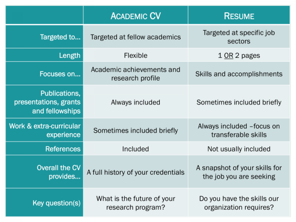

## Preparing your job materials: The Resume

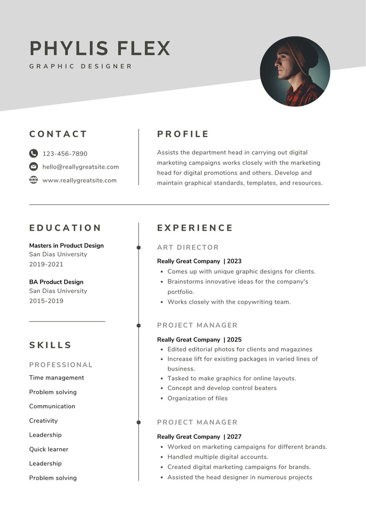

- **NOT a log of your job history**
- **NOT a summary of your skills**
- **Can hurt your chances at getting a job if done incorrectly**
- **Resume is your marketing tool**
  - selling yourself to potential employers
- **Your goal is to get potential employers to buy into what you are selling and give you an interview**

## Making your resume as effective as possible

**Your goal is to clearly articulate how your skills and experiences align to the criteria defined by the job posting**

**You should always take the time to tailor your resume to the job opportunity for which you are applying**

**Carefully study the job listing (and related listings) to identify skills, experience, education and other qualifications the potential employer is looking to find**

**Focus on the “requirements,” “skills” or “qualifications” sections and look for buzzwords**

## Be concise

- **Recruiters receive dozens of applications for some positions. The first step involves quickly skimming through submissions and eliminating candidates who clearly are not qualified.**
- **A resume should typically be a single page**
  - As you gain job experiences or if you have information that is highly relevant to the position, you can expand to two pages (maximum)
- **Look at your resume and ask:**
  - Can a hiring manager see my main credentials right away?
  - Does critical information jump off the page?
  - Do I effectively sell myself on the top quarter of the first page?

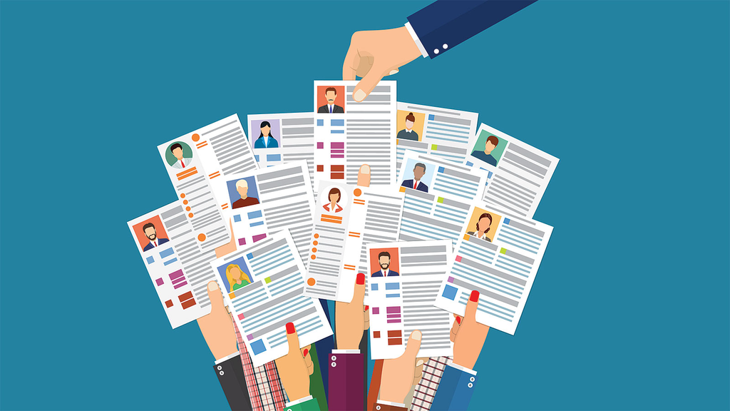

## Resume Format

- **A traditional format that is flexible and can be used by applicants with any level of experience:**
  - **Contact Information** – contact details must be outlined near the top.
  - **Career Objective** – This type of resume introduction can be used by anyone, and allows job-seekers to tailor their resume to their employer.
  - **Education** – Your degrees and certifications (if relevant) should be highlighted.
  - **Work Experience** – highlight previous work related to the position
  - **Additional Skills** – Your skills section can be used to highlight skills or personal attributes relevant to the position.
  - **Awards & Honors** – mention your most impressive

## Contact Information and Career Objectives

- **Contact Info:**
  - Name (largest font on page, middle initial is optional)
  - Mailing Address
  - Telephone Number (check that you have an appropriate voicemail message)
  - Email Address (make sure it’s appropriate, don’t use your sexypanda45@gmail.com)
  - Link to online portfolio (LinkedIn, Researchgate, etc.)
- **Career Objective**
  - This is a 2-3 sentence statement that provides an overview of your skills and experience.
  - Typical for entry-level candidates

**Recent biology graduate of Shepherd University seeking a laboratory research position. Conducted an independent research project on stem cell proliferation in the developing fruit fly brain. Looking to join a motivated research team where I can apply my skills to answer new, exciting scientific questions.**

## Education section

- **Having a solid education section helps to display the foundation of your knowledge and expertise.**
- **College students that lack professional experience benefit from emphasizing their education by placing it before the professional experience section.**
- **Include:**
  - University name
  - Location (city, state)
  - Date of graduation (month, year)
  - Degree(s)
  - GPA (only include if your GPA is above 3.0, format: GPA: 3.5/4.0)

## Relevant work experience

- **This will eventually be the core of your resume, where you prove the skills you’ve listed in your qualifications summary and/or career objective.**
  - “Relevant Experience” or “Work Experience” or “Professional Experience.”
  - List only experience that is relevant to the job you are applying for.
  - List your work experiences in reverse chronological order
- **For each position, create a heading including the company’s name, city and state, your title, and the dates of employment (month and year).**
- **Include 1-3 bullet points that detail your main duties and achievements.**
  - A strong bullet point has:
    - 1st: Action Verb (should always be first)
    - 2nd: Quantifiable Point
    - 3rd: Specific and relevant job duty

## Relevant work experience

- **Use non-science work experiences to highlight important transferable skills**
  - leadership, working in teams, managing, etc.

**EXAMPLES:**

**Trained 3 undergraduate students, taught basic microscopy skills and guided their research through the semester**

**Conducted weekly wetland monitoring surveys, measured turtle species abundance and water quality**

**PRO-TIP**: Find key verbs and occupation-specific nouns inside the job listing, then spread them cleverly throughout your resume

## The skills section

- **Listing tons of skills on your resume doesn’t actually prove you’re skilled, but it is important to highlight your relevant capabilities throughout your resume to catch the eye of a potential employer**
  - is the ability to lift 40lbs relevant?
- **Working various skills into the introduction and work experience sections will strengthen your candidacy.**
- **The skills section is where you will highlight and detail important skill that are *relevant* to the position.**
  - think about the order you present them
  - more is not always better
- **There are two kinds of skills that can be included on a resume: *hard* skills and *soft* skills**

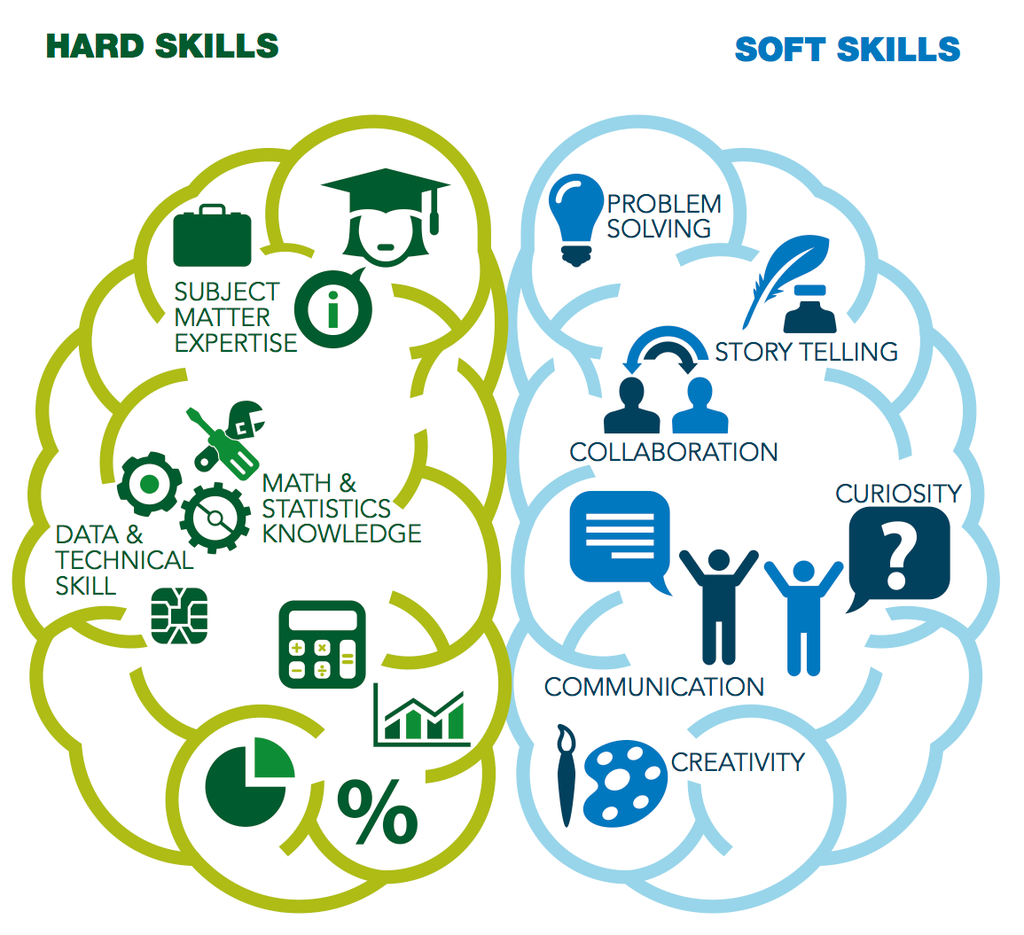

## Awards, honors, or activities

- **Adds another layer of customization to your resume by providing further evidence of your abilities and success**
- **Can allow you to stand out from your competition (but it is at the end, so might not be taken into account)**
- **Some items to consider adding:**
  - Grants
  - Academic Honors
  - Scholarships
  - Volunteer positions
  - Professional Affiliations

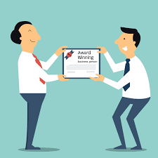

## Stylize your resume

- **Choose a suitable font and size: largely dependent on your preference.**
  - Choose easy-to-read fonts
  - Use the same font throughout
  - Change sizes in descending order for your name, headers, and bullet points.
  - Many resumes follow a 24 pt, 12 pt, 10 pt format.
- **Don’t reduce size to fit everything on one page (no less than 10 pt)**
- **Don’t pick wacky fonts**
- **Don’t have one uniform text size throughout**
- **If you use color, use it sparaingly**
- **There are TONS of ready-made resume templates for Word available online. Find an appealing one and fill it in with your details!**

## Workshop assignment, upcoming

- **Find an open job for which you currently qualify**
- **Prepare a one-page resume following the general format we’ve discussed here tailored to that** position.
- **The goal of this assignment is for you to prepare a resume that you can work to improve over time as you get closer to applying for jobs.**
- **In your document, provide a link to the job you chose and a one sentence description of it. This assignment is due by 5pm on Friday, October 22nd.**